# Biostat 203B Homework 4 (Draft)

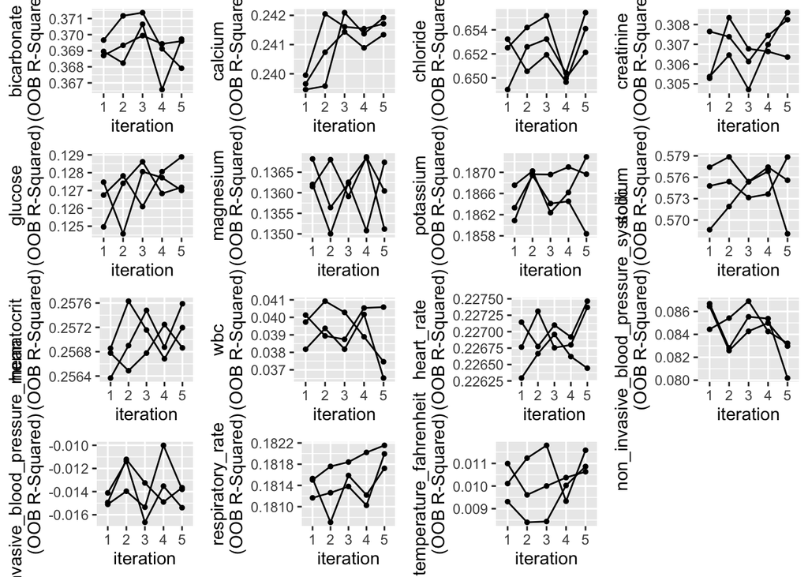

```r
plotModelError(miceObj, vars = 'allNumeric')
```

The Model OOB Error shows the the OOB accuracy for classification, and r-squared for regression. We could find most of the error is in the reasonable range.

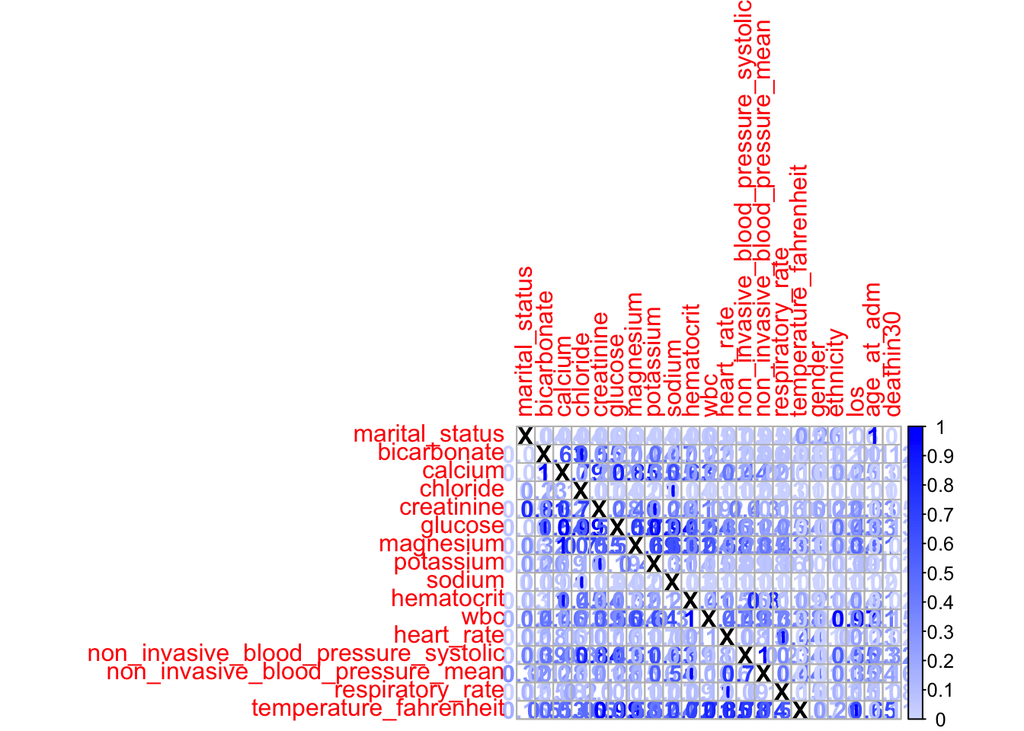

```r
plotVarImportance(miceObj)
```

Variable Importance shows the importance of each variable.

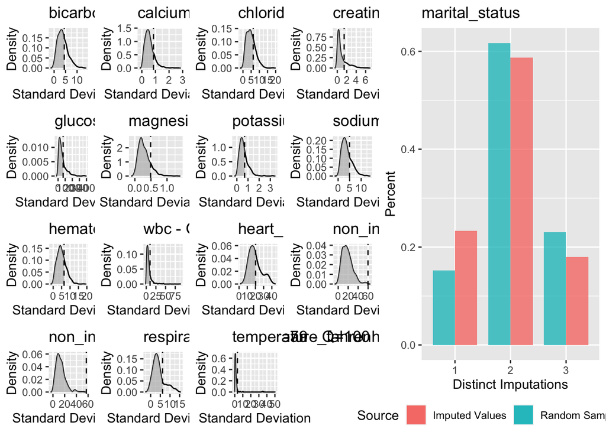

```r
plotImputationVariance(miceObj, ncol = 2, widths = c(5, 3))
```

In the Imputed Variance Between Datasets,the standard deviation of the imputed values is calculated for each sample. This is then compared to the total population standard deviation. Percentage of the samples with a SD below the population SD is shaded in the densities above, and the Quantile is shown in the title.

6. Obtain a complete data set by averaging the 3 imputed data sets.

```r
dataList <- completeData(miceObj)
head(dataList[[1]], 10)
```

```
##     gender              ethnicity marital_status        los age_at_adm
##  1:      F BLACK/AFRICAN AMERICAN        MARRIED  0.4975347         76
##  2:      M                UNKNOWN         SINGLE  8.3573727         51
##  3:      F                  WHITE        MARRIED  1.3919676         61
##  4:      M        HISPANIC/LATINO        MARRIED  2.2807523         58
##  5:      M BLACK/AFRICAN AMERICAN        MARRIED  3.2146181         70
##  6:      M                UNKNOWN        MARRIED  3.1586574         78
##  7:      M                  WHITE         SINGLE  1.0702894         40
##  8:      M BLACK/AFRICAN AMERICAN        MARRIED  3.8453588         73
##  9:      F BLACK/AFRICAN AMERICAN         SINGLE  4.9095370         58
## 10:      F                  WHITE        MARRIED 10.0727894         60
##     bicarbonate calcium chloride creatinine glucose magnesium potassium sodium
##  1:          23     9.2      103        2.2     144       2.0       4.2    139
##  2:          24     9.5      109        3.4      86       2.2       3.7    146
##  3:          19     8.0      107        0.8      89       1.7       3.6    142
```

[output cut: 40 more lines]

```r
dataList %>%
  saveRDS(str_c("./dataList.rds"))
```

```r
 dummy_cols(dataList[1],
           remove_first_dummy = TRUE,
           remove_selected_columns = TRUE) -> data.1
```

```r
 dummy_cols(dataList[2],
           remove_first_dummy = TRUE,
           remove_selected_columns = TRUE) -> data.2
```

```r
 dummy_cols(dataList[3],
           remove_first_dummy = TRUE,
           remove_selected_columns = TRUE) -> data.3
```

```r
data <- (data.1 + data.2 + data.3) / 3
```

```r
data %>%
  saveRDS(str_c("./data.rds"))
```

## Q2. Predicting 30-day mortality

Develop at least two analytic approaches for predicting the 30-day mortality of patients admitted to ICU using demographic information (gender, age, marital status, ethnicity), first lab measurements during ICU stay, and first vital measurements during ICU stay. For example, you can use (1) logistic regression (`glm()` function), (2) logistic regression with lasso penalty (glmnet package), (3) random forest (randomForest package), or (4) neural network.

1. Partition data into 80% training set and 20% test set. Stratify partitioning according the 30-day mortality status.

```r
library(dplyr)
train <- sample_frac(data, 0.8)
sid <- as.numeric(rownames(train)) # because rownames() returns character
test <- data[-sid, ]
```

```r
train %>%
  saveRDS(str_c("./train.rds"))
```

```r
test %>%
  saveRDS(str_c("./test.rds"))
```

```r
train <- readRDS("./train.rds")
```

```r
test <- readRDS("./test.rds")
```

```r
names(train)[names(train) ==
               ".data.Dataset_1.ethnicity_BLACK/AFRICAN AMERICAN"] <- "ethnicity_black_africanamerican"
names(test)[names(test) ==
              ".data.Dataset_1.ethnicity_BLACK/AFRICAN AMERICAN"] <- "ethnicity_black_africanamerican"
names(train)[names(train) ==
               ".data.Dataset_1.ethnicity_HISPANIC/LATINO"] <- "ethnicity_hisl"
names(test)[names(test) ==
              ".data.Dataset_1.ethnicity_HISPANIC/LATINO"] <- "ethnicity_hisl"
names(train)[names(train) ==
               ".data.Dataset_1.ethnicity_UNABLE TO OBTAIN"] <- "ethnicity_un"
names(test)[names(test) ==
              ".data.Dataset_1.ethnicity_UNABLE TO OBTAIN"] <- "ethnicity_un"
```

## 1.USING GLM

1.2. Train the models using the training set.

```r
logistic <- glm(train$.data.Dataset_1.deathin30_Yes~.
                  ,  binomial(link='logit'), data = train)
```

```r
summary(logistic)
```

```
##
## Call:
## glm(formula = train$.data.Dataset_1.deathin30_Yes ~ ., family = binomial(link = "logit"),
##     data = train)
##
## Deviance Residuals:
##     Min       1Q   Median       3Q      Max
## -3.5633  -0.4482  -0.3230  -0.2281   4.5217
##
## Coefficients:
##                                                        Estimate Std. Error
## (Intercept)                                          -4.063e+00  8.694e-01
## .data.Dataset_1.los                                   1.538e-02  2.631e-03
## .data.Dataset_1.age_at_adm                            3.291e-02  1.350e-03
## .data.Dataset_1.bicarbonate                          -1.278e-01  4.728e-03
## .data.Dataset_1.calcium                              -1.666e-01  2.360e-02
## .data.Dataset_1.chloride                             -1.021e-01  4.993e-03
## .data.Dataset_1.creatinine                            2.150e-02  1.147e-02
## .data.Dataset_1.glucose                               1.406e-03  2.084e-04
## .data.Dataset_1.magnesium                             7.779e-02  3.497e-02
## .data.Dataset_1.potassium                             2.012e-01  2.528e-02
## .data.Dataset_1.sodium                                9.869e-02  5.767e-03
## .data.Dataset_1.hematocrit                           -2.741e-03  2.958e-03
## .data.Dataset_1.wbc                                   1.307e-02  1.384e-03
## .data.Dataset_1.heart_rate                            8.761e-03  9.424e-04
## .data.Dataset_1.non_invasive_blood_pressure_systolic -6.145e-04  7.391e-04
## .data.Dataset_1.non_invasive_blood_pressure_mean      1.940e-05  1.101e-05
## .data.Dataset_1.respiratory_rate                      3.118e-02  2.888e-03
## .data.Dataset_1.temperature_fahrenheit               -2.926e-02  3.492e-03
## .data.Dataset_1.gender_M                             -4.543e-02  3.894e-02
## .data.Dataset_1.ethnicity_ASIAN                       9.878e-01  6.090e-01
## ethnicity_black_africanamerican                       6.267e-01  6.039e-01
## ethnicity_hisl                                        7.567e-01  6.109e-01
## .data.Dataset_1.ethnicity_OTHER                       8.729e-01  6.067e-01
## ethnicity_un                                          1.906e+00  6.119e-01
## .data.Dataset_1.ethnicity_UNKNOWN                     1.731e+00  6.017e-01
## .data.Dataset_1.ethnicity_WHITE                       8.142e-01  6.006e-01
## .data.Dataset_1.marital_status_MARRIED               -9.799e-03  7.577e-02
## .data.Dataset_1.marital_status_SINGLE                 3.000e-02  8.044e-02
## .data.Dataset_1.marital_status_WIDOWED                5.602e-02  8.506e-02
```

[output cut: 25 more lines]

```
## .data.Dataset_1.ethnicity_UNKNOWN                      2.877  0.00402 **
## .data.Dataset_1.ethnicity_WHITE                        1.356  0.17521
## .data.Dataset_1.marital_status_MARRIED                -0.129  0.89710
## .data.Dataset_1.marital_status_SINGLE                  0.373  0.70915
## .data.Dataset_1.marital_status_WIDOWED                 0.659  0.51013
## ---
## Signif. codes:  0 '***' 0.001 '**' 0.01 '*' 0.05 '.' 0.1 ' ' 1
##
## (Dispersion parameter for binomial family taken to be 1)
##
##     Null deviance: 25599  on 40037  degrees of freedom
## Residual deviance: 21641  on 40009  degrees of freedom
## AIC: 21699
##
## Number of Fisher Scoring iterations: 6
```

1.3. Compare model prediction performance on the test set.

```r
test$logistic_prob <- predict(logistic, test, type = "response")
length(test$logistic_prob)
```

```
## [1] 10010
```

```r
test <- test  %>%
  mutate(model_pred = (logistic_prob > .95) ,
                          death = .data.Dataset_1.deathin30_Yes )
```

```r
test <- test %>% mutate(accurate = 1*(model_pred == death))
sum (test$accurate) / nrow(test)
```

```
## [1] 0.9021978
```

## 2.USING RANDOM FOREST

2.2. Train the models using the training set.

```r
library(randomForest)
```

```r
train$.data.Dataset_1.deathin30_Yes <-
  as.character(train$.data.Dataset_1.deathin30_Yes)
train$.data.Dataset_1.deathin30_Yes <-
  as.factor(train$.data.Dataset_1.deathin30_Yes)
rf <- randomForest(formula = train$.data.Dataset_1.deathin30_Yes ~.
            , ntree = 10, nodesize = 5, data = train,
             importance = TRUE, proximity = TRUE)
```

2.3. Compare model prediction performance on the test set.

```r
test_matrix = table(predict(rf, test), test$.data.Dataset_1.deathin30_Yes)
sum(diag(test_matrix)) / sum(test_matrix)
```

```
## [1] 0.956044
```

```r
summary(rf)
```

```
##                 Length     Class  Mode
## call                     7 -none- call
## type                     1 -none- character
## predicted            40038 factor numeric
## err.rate                30 -none- numeric
## confusion                6 -none- numeric
## votes                80076 matrix numeric
## oob.times            40038 -none- numeric
## classes                  2 -none- character
## importance             112 -none- numeric
## importanceSD            84 -none- numeric
## localImportance          0 -none- NULL
## proximity       1603041444 -none- numeric
## ntree                    1 -none- numeric
## mtry                     1 -none- numeric
## forest                  14 -none- list
## y                    40038 factor numeric
## test                     0 -none- NULL
## inbag                    0 -none- NULL
## terms                    3 terms  call
```

```r
train$.data.Dataset_1.deathin30_Yes <-
  as.character(train$.data.Dataset_1.deathin30_Yes)
train$.data.Dataset_1.deathin30_Yes <-
  as.factor(train$.data.Dataset_1.deathin30_Yes)
rf2 <- randomForest(formula = train$.data.Dataset_1.deathin30_Yes ~.
            , ntree = 20, nodesize = 5, data = train,
             importance = TRUE, proximity = TRUE)
```

```r
test_matrix = table(predict(rf2, test), test$.data.Dataset_1.deathin30_Yes)
sum(diag(test_matrix)) / sum(test_matrix)
```

```
## [1] 0.9608392
```

```r
summary(rf2)
```

```
##                 Length     Class  Mode
## call                     7 -none- call
## type                     1 -none- character
## predicted            40038 factor numeric
## err.rate                60 -none- numeric
## confusion                6 -none- numeric
## votes                80076 matrix numeric
## oob.times            40038 -none- numeric
## classes                  2 -none- character
## importance             112 -none- numeric
## importanceSD            84 -none- numeric
## localImportance          0 -none- NULL
## proximity       1603041444 -none- numeric
## ntree                    1 -none- numeric
## mtry                     1 -none- numeric
## forest                  14 -none- list
## y                    40038 factor numeric
## test                     0 -none- NULL
## inbag                    0 -none- NULL
## terms                    3 terms  call
```

### We could find the random forest with more tree numbers have higher accuracy.